# Módulo 1. Introducción a la morfometría geométrica de contornos de otolitos

Curso corto: Análisis de contornos de otolitos con R

Luis Cubillos

Noviembre 2026

# Objetivos del curso

Al finalizar el curso el participante será capaz de:

1. Explicar qué es la **forma** y por qué el contorno del otolito *sagitta* se usa como marca natural para identificar stocks.
2. **Preparar imágenes** en R: lectura, escala de grises y binarización.
3. **Extraer el contorno** y obtener **pseudolandmarks** equiespaciados.
4. **Organizar los datos** de contornos en archivos CSV o XLSX reproducibles.
5. Describir el contorno con la **Transformada Elíptica de Fourier** normalizada.
6. Explorar la variación de forma con un **Análisis de Componentes Principales** (ACP) y reconstruir las formas asociadas a cada eje.

Texto guía: Claude, J. (2008). *Morphometrics with R*. Springer.

# Programa

| Módulo | Contenido | Claude (2008) |
| --- | --- | --- |
| 1 | Introducción a la morfometría geométrica de contornos | Cap. 1, 2.1, 5 |
| 2 | Imágenes en R y binarización; extracción del contorno | Secc. 2.1.1, 2.2.5–2.2.6 |
| 3 | Pseudolandmarks a lo largo del contorno; descriptores | Secc. 2.3.3, 5.2.1 |
| 4 | Preparación de datos en CSV o XLSX | Secc. 2.1.2, 2.4 |
| 5 | Fourier elíptico y normalización | Secc. 5.2.3 |
| 6 | Análisis de componentes principales de contornos | Secc. 6.1.2 |

Datos de ejemplo: un otolito de sardina común (imagen) y contornos de otolitos de merluza de cola (*Macruronus magellanicus*) de tres zonas: Chiloé, Aysén y Magallanes.

# ¿Por qué otolitos?

# El otolito *sagitta* como marca natural

- Los otolitos son estructuras de carbonato de calcio del oído interno de los peces; la *sagitta* es el más grande en la mayoría de los teleósteos.
- Crecen durante toda la vida y **no se reabsorben**: su forma integra la historia del individuo.
- La forma del contorno refleja factores **genéticos** y **ambientales** (temperatura, alimentación, tasa de crecimiento).
- Grupos que habitan ambientes distintos el tiempo suficiente tienden a mostrar diferencias de forma → **identificación de stocks** (Campana y Casselman 1993; Cadrin et al. 2005).
- La forma también es específica de cada especie: atlas de otolitos para identificación de presas y restos arqueológicos (Campana 2004).

La forma del otolito cambia con la ontogenia: antes de comparar grupos hay que preguntarse **a partir de qué talla se estabiliza la forma**.

# Un otolito, un contorno

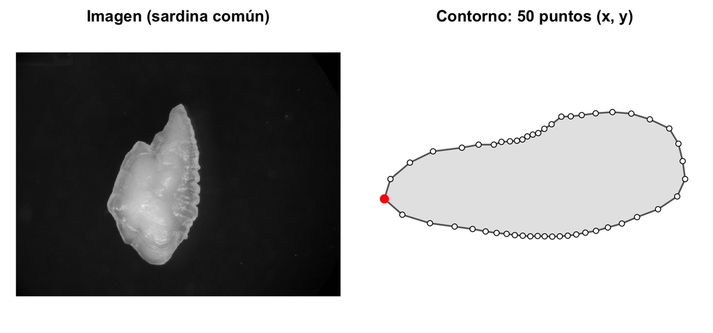

El contorno es una **curva cerrada**: el análisis convierte esa curva en números comparables entre individuos.

# Morfometría: conceptos básicos

# Morfología y morfometría

- **Morfología**: ciencia biológica que estudia la forma de los organismos y sus transformaciones (alometría, simetría, segmentación, plan corporal…).
- **Morfometría**: *estudio estadístico de la forma y el tamaño, y de su covariación con otras variables* (Claude 2008, p. 1).

**Forma**: propiedad geométrica de un objeto que es **invariante** a la traslación, la rotación y el cambio de escala.

**Tamaño**: un escalar basado en distancias o coordenadas de puntos del objeto (p. ej., perímetro, área, tamaño del centroide).

Color y textura son atributos del objeto, pero **no** son forma.

# Forma = lo que queda al quitar posición, orientación y escala

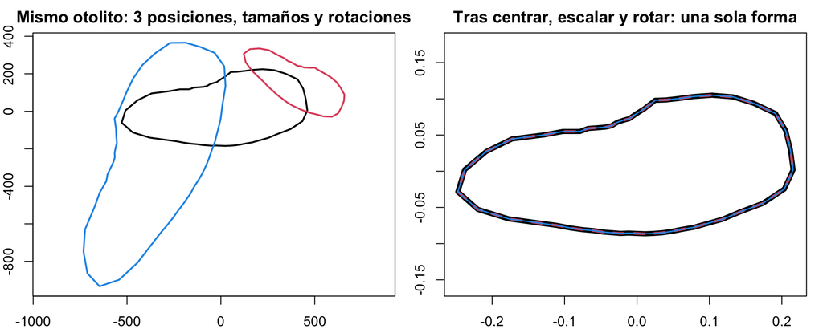

La morfometría geométrica trabaja con **coordenadas** y elimina explícitamente esos tres efectos antes de comparar.

# Breve historia

- **Morfometría tradicional**: distancias, ángulos y proporciones *ad hoc* analizados con estadística uni-, bi- y multivariada.
- **D’Arcy Thompson (1917)**, *On Growth and Form*: grillas de deformación entre especies de peces → la forma como **transformación** geométrica.
- Fines del siglo XX: la “revolución morfométrica” (Rohlf y Marcus 1993): superposición de Procrustes, *thin-plate splines*, **análisis de Fourier de contornos**, EDMA.
- Hoy la morfometría considera la forma **como un todo** y la interdependencia de sus partes, con descriptores y estadística propios (Claude 2008, cap. 1).

# Morfometría tradicional vs. geométrica

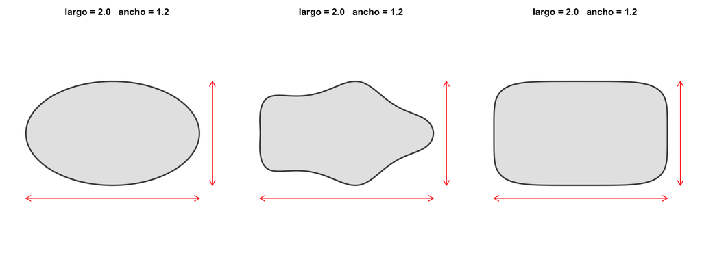

Tres formas con **el mismo largo y ancho**: las medidas lineales no capturan la forma. La morfometría geométrica conserva la **posición relativa** de todos los puntos durante el análisis, por lo que permite **reconstruir** la forma.

# Dimensiones

- **k = 1**: forma, tamaño y forma se superponen; basta la estadística clásica (p. ej., ANOVA de longitudes).
- **k = 2 o 3**: volúmenes, superficies, **contornos**, posiciones de puntos; separar tamaño y forma ya no es trivial (Claude 2008, sección 1.2).

El otolito *sagitta* se fotografía en **2D** (vista de la cara interna o *sulcus*): su contorno es una curva cerrada en el plano.

# Landmarks y pseudolandmarks

# Landmarks (puntos homólogos)

Un **landmark** es un punto cuya posición es **comparable entre objetos**. Bookstein (1991) reconoce tres tipos:

| Tipo | Definición | Ejemplo |
| --- | --- | --- |
| I | Yuxtaposición discreta de tejidos; homología biológica más fuerte | Foramen, unión de suturas |
| II | Máximo de curvatura; posible base en el desarrollo | Punta de un proceso |
| III | Extremo geométrico: fin de un diámetro, centroide, intersección | Punto más anterior |

- **Landmark difuso** (*fuzzy*): estructura reconocible pero sin límites nítidos.
- **Pseudolandmarks**: puntos definidos **por construcción**, por ejemplo equiespaciados sobre un contorno.

Claude (2008), sección 1.2; Bookstein (1991).

# ¿Landmarks o contornos en otolitos?

- El otolito tiene **pocos landmarks homólogos** claros (punta del rostro, antirostro, excisura) y su posición puede ser ambigua.
- Gran parte de la información está en la **forma del borde**: lóbulos, crenulaciones, curvatura dorsal y ventral.
- Solución: describir el **contorno completo** con muchos **pseudolandmarks** muestreados regularmente.

[figure not shown]

# Configuraciones

- Una **configuración** es el conjunto de coordenadas de los landmarks (o pseudolandmarks) de un objeto: una matriz **p × k** (puntos × dimensiones).
- Todas las configuraciones deben tener **el mismo número de puntos, en el mismo orden**: el punto *i* de un otolito se compara con el punto *i* de otro.
- En contornos, eso exige el **mismo punto de inicio** y el **mismo sentido** de recorrido.

```r
dim(oto)      # 50 pseudolandmarks x 2 coordenadas
```

```
#> [1] 50  2
```

```r
head(oto, 3)
```

```
#>           x          y
#> 1 -515.5837  -64.71065
#> 2 -456.5837 -116.71065
#> 3 -365.5837 -144.71065
```

# Métodos para analizar contornos

# Del contorno a variables de forma

Claude (2008, cap. 5) describe tres familias de análisis de Fourier de contornos cerrados:

| Método | Qué se descompone | Ventaja | Limitación |
| --- | --- | --- | --- |
| Fourier de **radios** (polar) | Radio *r(θ)* desde el centroide | Simple, pocos coeficientes | Falla si un radio corta el contorno 2 veces; muestreo desigual |
| Fourier del **ángulo tangente** (Zahn y Roskies 1972) | Cambio del ángulo tangente a lo largo del perímetro | Admite concavidades | Sensible al ruido de digitalización |
| Fourier **elíptico** (Kuhl y Giardina 1982) | *x(t)* e *y(t)* por separado, en función de la abscisa curvilínea | Cualquier contorno cerrado; normalizable; reconstruye bien con pocos armónicos | 4 coeficientes por armónico |

También existen el análisis de *eigenshape* y las *wavelets*. En otolitos, el **Fourier elíptico normalizado** es el más usado y es el que veremos.

# Índices de forma (enfoque clásico)

Antes de Fourier, la forma se resumía con índices adimensionales calculados a partir de área (*A*), perímetro (*P*), largo (*L*) y ancho (*W*):

| Índice | Fórmula | Círculo |
| --- | --- | --- |
| Circularidad | $P^2 / A$ | $4\pi \approx 12.6$ |
| Redondez | $4A / (\pi L^2)$ | 1 |
| Rectangularidad | $A / (L \cdot W)$ | $\pi/4$ |
| Elipticidad | $(L - W) / (L + W)$ | 0 |
| Razón de aspecto | $L / W$ | 1 |

Útiles y fáciles de interpretar, pero **resumen** la forma: no permiten reconstruirla. Se calculan en el módulo 3.

# Flujo de trabajo del curso

**Imagen** → escala de grises → **binarización** → **contorno** (píxeles) → **pseudolandmarks** (50 puntos) → **archivo CSV/XLSX** → **Fourier elíptico normalizado** → selección de armónicos → **ACP** → formas reconstruidas

- Módulos 2 y 3: de la imagen a los pseudolandmarks.
- Módulo 4: datos ordenados y reproducibles.
- Módulos 5 y 6: descriptores de forma y exploración multivariada.

# ¿Por qué R?

- Gratuito, multiplataforma y con miles de paquetes.
- Todo el análisis queda en un **script**: se corrigen errores, se reutiliza con nuevos datos y queda el registro de lo hecho (Claude 2008, sección 1.3).
- Las funciones de Claude (2008) son cortas y legibles: se entiende **qué** hace cada paso.

Paquetes usados en el curso:

```r
install.packages(c("pixmap", "readxl", "writexl", "magick"))
# Funciones de Claude (2008) incluidas en la carpeta R/ del curso:
# Conte, regularradius, efourier, iefourier, NEF, elipse
for (f in list.files("R", full.names = TRUE)) source(f)
```

# Recomendaciones para la toma de imágenes

- Mismo **aumento**, iluminación y fondo en todas las fotos.
- Incluir una **escala** (regla o micrómetro) en la imagen.
- Misma **orientación**: otolito izquierdo, cara interna (*sulcus*) hacia la cámara, rostro hacia la izquierda.
- Fondo **contrastante** (negro con luz reflejada) para facilitar la binarización.
- Registrar en una planilla: código del otolito, zona, talla, sexo, edad, lado.

La calidad de los datos determina la calidad de los resultados: el error de medición proviene tanto del operador como de los instrumentos (Claude 2008, cap. 2).

# Referencias

- Bookstein, F.L. (1991). *Morphometric Tools for Landmark Data*. Cambridge University Press.
- Cadrin, S.X., Friedland, K.D. y Waldman, J.R. (eds.) (2005). *Stock Identification Methods*. Elsevier Academic Press.
- Campana, S.E. (2004). *Photographic Atlas of Fish Otoliths of the Northwest Atlantic Ocean*. NRC Research Press.
- Campana, S.E. y Casselman, J.M. (1993). Stock discrimination using otolith shape analysis. *Can. J. Fish. Aquat. Sci.* 50: 1062–1083.
- **Claude, J. (2008). *Morphometrics with R*. Springer.**
- Kuhl, F.P. y Giardina, C.R. (1982). Elliptic Fourier features of a closed contour. *Comput. Graph. Image Process.* 18: 236–258.
- Rohlf, F.J. y Marcus, L.F. (1993). A revolution in morphometrics. *Trends Ecol. Evol.* 8: 129–132.
- Thompson, D’A.W. (1917). *On Growth and Form*. Cambridge University Press.
- Zahn, C.T. y Roskies, R.Z. (1972). Fourier descriptors for plane closed curves. *IEEE Trans. Comput.* C-21: 269–281.